# CBanks_Week10CaseStudy

C. Banks

July 27, 2016

# INTRODUCTION

## This assignment presents an analysis of the Chulwalr nation flower sales with seasonal data provided for interpretation of forecast vs actual.

## The purpose of this project will be to 1) determine relationships in flower sales with specific indicators and 2) identify a model for forecasting production of the flowers.

# I-PREPARATION STAGE.

## -Set working directory.

## -Load libraries.

## -Import data into R.

## Import data into R – 3 .csv files are provided.

## Files downloaded from SMU/MSDS6360/10.2.

```r
library(repmis)
library(downloader)
library(data.table)
library(timeSeries)
library(zoo)
library(tseries)
library(xts)
library(fpp)
library(tcltk)
library(plyr)
library(dplyr)
```

```r
library(ggplot2)
library(reshape2)
library(latticeExtra)
library(googleVis)
library(quantmod)
library(PerformanceAnalytics)
DataAsIs <- read.csv("ImportedAsIsDataChulwalar.csv",sep=";",fill=T)
DataPlanned <- read.csv("ImportedPlanDataChulwalar.csv",sep=";",fill=T)
DataIndicators <- read.csv("ImportedIndicatorsChulwalar.csv",sep=";",fill=T)
## Check Data
head(DataAsIs)
```

```
##   Total.As.Is   X2008   X2009   X2010   X2011   X2012   X2013   X2014
## 1         Jan 2313221 2610573 2760688 3112861 3093088 4119526 4308161
## 2         Feb 1950131 2371327 2918333 2926663 3679308 3535744 4155378
## 3         Mar 2346635 2743786 3227041 3294784 3433364 3560974 3924332
## 4         Apr 2039787 2125308 1613888 2577079 2714899 3760065 3659121
## 5         May 1756964 1850073 2550157 2774068 3011767 2959933 3898758
## 6         Jun 1458302 1836222 2317645 2378227 2726028 2787898 3313891
```

```r
head(DataPlanned)
```

```
##   Total.Plan   X2008   X2009   X2010   X2011   X2012   X2013   X2014
## 1        Jan 2243103 2547980 2965885 3113110 3895396 3580325 4474000
## 2        Feb 2162705 2247049 2751170 2883766 3588151 3863212 4185565
## 3        Mar 2720911 2731156 2906493 2957893 3787240 3606083 4278119
## 4        Apr 2011182 2020158 2383358 2601648 3036434 3213575 3985542
## 5        May 1877757 2098038 2246893 2370949 2907891 3139128 3605973
## 6        Jun 1819924 1927995 1992851 2339881 2707822 2998610 3515173
```

```r
head(DataIndicators)
```

```
##   Change.in.export.prices X2008 X2009 X2010 X2011 X2012 X2013 X2014
## 1                     Jan  97.4  98.3  99.0 100.7 102.8 104.5    NA
## 2                     Feb  97.8  98.9  99.4 101.3 103.5 105.1    NA
## 3                     Mar  98.3  98.7  99.9 101.9 104.1 105.6    NA
## 4                     Apr  98.1  98.8 100.0 101.9 103.9 105.1    NA
## 5                     Mai  98.7  98.7  99.9 101.9 103.9 105.5    NA
## 6                     Jun  98.9  99.0  99.9 102.0 103.7 105.6    NA
```

```r
## Structure of data file
str(DataAsIs)
```

```
## 'data.frame':    97 obs. of  8 variables:
##  $ Total.As.Is: Factor w/ 21 levels "","Apr","Aug",..: 9 8 13 2 14 11 10 3 18 16 ...
##  $ X2008      : int  2313221 1950131 2346635 2039787 1756964 1458302 1679637 1639670 2882886 2959716 ...
##  $ X2009      : int  2610573 2371327 2743786 2125308 1850073 1836222 1797311 1851968 3271171 2818888 ...
##  $ X2010      : int  2760688 2918333 3227041 1613888 2550157 2317645 1474144 2148521 3898571 3348953 ...
##  $ X2011      : int  3112861 2926663 3294784 2577079 2774068 2378227 2222900 2991787 4151531 3318684 ...
##  $ X2012      : int  3093088 3679308 3433364 2714899 3011767 2726028 2483834 3055655 4200796 4228724 ...
##  $ X2013      : int  4119526 3535744 3560974 3760065 2959933 2787898 2828744 3084113 5107775 4562144 ...
##  $ X2014      : int  4308161 4155378 3924332 3659121 3898758 3313891 3595106 3502426 5619059 5274287 ...
```

```r
str(DataPlanned)
```

```
## 'data.frame':    96 obs. of  8 variables:
##  $ Total.Plan: Factor w/ 19 levels "","Apr","Aug",..: 7 6 11 2 12 9 8 3 15 14 ...
##  $ X2008     : int  2243103 2162705 2720911 2011182 1877757 1819924 1682196 1893171 3325711 2662148 ...
##  $ X2009     : int  2547980 2247049 2731156 2020158 2098038 1927995 1783692 1907705 3124040 3102251 ...
##  $ X2010     : int  2965885 2751170 2906493 2383358 2246893 1992851 2023434 2244997 3257717 3536338 ...
##  $ X2011     : int  3113110 2883766 2957893 2601648 2370949 2339881 2105328 2341623 4086297 3640827 ...
##  $ X2012     : int  3895396 3588151 3787240 3036434 2907891 2707822 2619486 3784557 4987460 4367319 ...
##  $ X2013     : int  3580325 3863212 3606083 3213575 3139128 2998610 2785453 3083654 5143757 4149334 ...
##  $ X2014     : int  4474000 4185565 4278119 3985542 3605973 3515173 3269444 3656112 5637391 5157781 ...
```

```r
str(DataIndicators)
```

```
## 'data.frame':    194 obs. of  8 variables:
##  $ Change.in.export.prices: Factor w/ 27 levels "","Apr","Aug",..: 15 11 19 2 18 17 16 3 25 22 ...
##  $ X2008                  : num  97.4 97.8 98.3 98.1 98.7 98.9 99.5 99.2 99.1 98.9 ...
##  $ X2009                  : num  98.3 98.9 98.7 98.8 98.7 99 99 99.2 98.9 98.9 ...
##  $ X2010                  : num  99 99.4 99.9 100 99.9 ...
##  $ X2011                  : num  101 101 102 102 102 ...
##  $ X2012                  : num  103 104 104 104 104 ...
##  $ X2013                  : num  104 105 106 105 106 ...
##  $ X2014                  : num  NA NA NA NA NA NA NA NA NA NA ...
```

## II-DATA TIDY AND CONVERT.

## Some overall comments on the data files:

## -In all 3 of the imported files, there are NA’s in row breaks and where data is missing for year.

## -There are multiple breaks or segments of data that can be made into separate datasets.

## -Datasets are segmented by Totals, Efak, Wuge, Etel, blue Etel, red Etel and Total Yearly.

## -For the Indicators file, there are ~14 categories of indicators.

## -Subset the files and transform the data to time series.

```r
## II-A Segment AsIs Datasets.
TotalAsIs <- c(DataAsIs [1:12,2],DataAsIs [1:12,3],DataAsIs [1:12,4],DataAsIs [1:12,5],DataAsIs [1:12,6],DataAsIs [1:12,7])
TotalAsIs2014 <- c(DataAsIs [1:12,8])
EfakAsIs <- c(DataAsIs [15:26,2],DataAsIs [15:26,3],DataAsIs [15:26,4],DataAsIs [15:26,5],DataAsIs [15:26,6],DataAsIs [15:26,7])
WugeAsIs <- c(DataAsIs [29:40,2],DataAsIs [29:40,3],DataAsIs [29:40,4],DataAsIs [29:40,5],DataAsIs [29:40,6],DataAsIs [29:40,7])
TotalEtelAsIs <- c(DataAsIs [43:54,2],DataAsIs [43:54,3],DataAsIs [43:54,4],DataAsIs [43:54,5],DataAsIs [43:54,6],DataAsIs [43:54,7])
BlueEtelAsIs <- c(DataAsIs [57:68,2],DataAsIs [57:68,3],DataAsIs [57:68,4],DataAsIs [57:68,5],DataAsIs [57:68,6],DataAsIs [57:68,7])
RedEtelAsIs <- c(DataAsIs [71:82,2],DataAsIs [71:82,3],DataAsIs [71:82,4],DataAsIs [71:82,5],DataAsIs [71:82,6],DataAsIs [71:82,7])
TotalYrlyAsIs <- c(DataAsIs [85,2],DataAsIs [85,3],DataAsIs [85,4],DataAsIs [85,5],DataAsIs [85,6],DataAsIs [85,7])

## II-B Segment Planned Datasets.
TotalPlanned <- c(DataPlanned [1:12,2],DataPlanned [1:12,3],DataPlanned [1:12,4],DataPlanned [1:12,5],DataPlanned [1:12,6],DataPlanned [1:12,7])
TotalPlanned2014 <- c(DataPlanned [1:12,8])
CoffeePlanned <- c(DataPlanned [15:26,2],DataPlanned [15:26,3],DataPlanned [15:26,4],DataPlanned [15:26,5],DataPlanned [15:26,6],DataPlanned [15:26,7])
SpicesPlanned <- c(DataPlanned [29:40,2],DataPlanned [29:40,3],DataPlanned [29:40,4],DataPlanned [29:40,5],DataPlanned [29:40,6],DataPlanned [29:40,7])
TeaTotalPlanned <- c(DataPlanned [43:54,2],DataPlanned [43:54,3],DataPlanned [43:54,4],DataPlanned [43:54,5],DataPlanned [43:54,6],DataPlanned [43:54,7])
LooseTeaPlanned <- c(DataPlanned [57:68,2],DataPlanned [57:68,3],DataPlanned [57:68,4],DataPlanned [57:68,5],DataPlanned [57:68,6],DataPlanned [57:68,7])
TeaBagPlanned <- c(DataPlanned [71:82,2],DataPlanned [71:82,3],DataPlanned [71:82,4],DataPlanned [71:82,5],DataPlanned [71:82,6],DataPlanned [71:82,7])
TotalYrlyPlanned <- c(DataPlanned [85,2],DataPlanned [85,3],DataPlanned [85,4],DataPlanned [85,5],DataPlanned [85,6],DataPlanned [85,7])


## II-C Segment Indicator Datasets.
ExpPriceChgInd <- c(DataIndicators [1:12,2],DataIndicators [1:12,3],DataIndicators [1:12,4],DataIndicators [1:12,5],DataIndicators [1:12,6],DataIndicators [1:12,7])
GovSatInd <- c(DataIndicators [15:26,2],DataIndicators [15:26,3],DataIndicators [15:26,4],DataIndicators [15:26,5],DataIndicators [15:26,6],DataIndicators [15:26,7])
AvgTempInd <- c(DataIndicators [29:40,2],DataIndicators [29:40,3],DataIndicators [29:40,4],DataIndicators [29:40,5],DataIndicators [29:40,6],DataIndicators [29:40,7])
BirthsInd <- c(DataIndicators [43:54,2],DataIndicators [43:54,3],DataIndicators [43:54,4],DataIndicators [43:54,5],DataIndicators [43:54,6],DataIndicators [43:54,7])
SatIndIndep <-c(DataIndicators [57:68,2],DataIndicators [57:68,3],DataIndicators [57:68,4],DataIndicators [57:68,5],DataIndicators [57:68,6],DataIndicators [57:68,7])
TotExUrbInd <-c(DataIndicators [71:82,2],DataIndicators [71:82,3],DataIndicators [71:82,4],DataIndicators [71:82,5],DataIndicators [71:82,6],DataIndicators [71:82,7])
TotExUrbInd2014 <-c(DataIndicators [71:82,8])
GlobPartyMbrsInd <- c(DataIndicators [85:96,2],DataIndicators [85:96,3],DataIndicators [85:96,4],DataIndicators [85:96,5],DataIndicators [85:96,6],DataIndicators [85:96,7])
GlobPartyMbrsInd2014 <-c(DataIndicators [85:96,8])
AvgExpPriceInd <- c(DataIndicators [99:110,2],DataIndicators [99:110,3],DataIndicators [99:110,4],DataIndicators [99:110,5],DataIndicators [99:110,6],DataIndicators [99:110,7])
EtelProdPriceInd <- c(DataIndicators [113:124,2],DataIndicators [113:124,3],DataIndicators [113:124,4],DataIndicators [113:124,5],DataIndicators [113:124,6],DataIndicators [113:124,7])
ChulwalarIndx <- c(DataIndicators [127:138,2],DataIndicators [127:138,3],DataIndicators [127:138,4],DataIndicators [127:138,5],DataIndicators [127:138,6],DataIndicators [127:138,7])
ChulwalarIndx2014 <-c(DataIndicators [127:138,8])
InflationInd <- c(DataIndicators [141:152,2],DataIndicators [141:152,3],DataIndicators [141:152,4],DataIndicators [141:152,5],DataIndicators [141:152,6],DataIndicators [141:152,7])
InflationInd2014 <-c(DataIndicators [141:152,8])
ChulwalarSpendDaysInd <- c(DataIndicators [155:166,2],DataIndicators [155:166,3],DataIndicators [155:166,4],DataIndicators [155:166,5],DataIndicators [155:166,6],DataIndicators [155:166,7])
ChulwalarSpendDaysInd2014 <-c(DataIndicators [155:166,8])
ChulwalarDaysInd <- c(DataIndicators [169:180,2],DataIndicators [169:180,3],DataIndicators [169:180,4],DataIndicators [169:180,5],DataIndicators [169:180,6],DataIndicators [166:180,7])
ChulwalarDaysInd2014 <-c(DataIndicators [169:180,8])
InflChulwalarDaysInd <- c(DataIndicators [183:194,2],DataIndicators [183:194,3],DataIndicators [183:194,4],DataIndicators [183:194,5],DataIndicators [183:194,6],DataIndicators [183:194,7])
InflChulwalarDaysInd2014 <-c(DataIndicators [183:194,8])


## ##########################################################
## II-D Convert vectorized data into time series.
## ##########################################################


TotalAsIsts<- ts(TotalAsIs , start=c(2008,1), end=c(2013,12), frequency=12)
TotalAsIsts2014 <- ts(TotalAsIs2014, start=c(2014,1), end=c(2014,12), frequency=12)
EfakAsIsts<- ts(EfakAsIs , start=c(2008,1), end=c(2013,12), frequency=12)
WugeAsIsts<- ts(WugeAsIs , start=c(2008,1), end=c(2013,12), frequency=12)
TotalEtelAsIsts<- ts(TotalEtelAsIs , start=c(2008,1), end=c(2013,12), frequency=12)
BlueEtelAsIsts<- ts(BlueEtelAsIs , start=c(2008,1), end=c(2013,12), frequency=12)
RedEtelAsIsts<- ts(RedEtelAsIs , start=c(2008,1), end=c(2013,12), frequency=12)
TotalYrlyAsIsts<- ts(TotalYrlyAsIs , start=c(2008,1), end=c(2013,12), frequency=12)


TotalPlannedts <- ts(TotalPlanned, start=c(2008,1), end=c(2013,12), frequency=12)
TotalPlanned2014ts <- ts(TotalPlanned2014, start=c(2014,1), end=c(2014,12), frequency=12)
CoffeePlannedts <- ts(CoffeePlanned, start=c(2008,1), end=c(2013,12), frequency=12)
SpicesPlannedts <- ts(SpicesPlanned, start=c(2008,1), end=c(2013,12), frequency=12)
TeaTotalPlannedts <- ts(TeaTotalPlanned, start=c(2008,1), end=c(2013,12), frequency=12)
LooseTeaPlannedts <- ts(LooseTeaPlanned, start=c(2008,1), end=c(2013,12), frequency=12)
TeaBagPlannedts <- ts(TeaBagPlanned, start=c(2008,1), end=c(2013,12), frequency=12)
TotalYrlyPlannedts <- ts(TotalYrlyPlanned, start=c(2008,1), end=c(2013,12), frequency=12)
```

# III-Basic Analysis

## -Time Series Plots.

## -Linear Relationships.

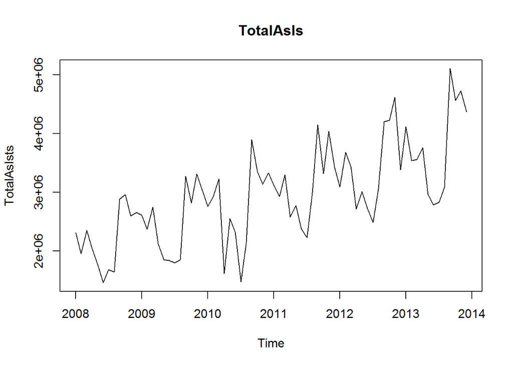

```r
plot(TotalAsIsts, col="black", main="TotalAsIs")
```

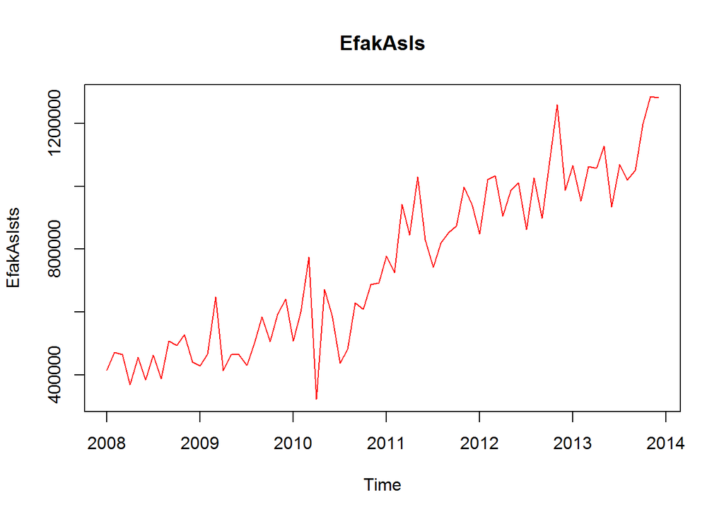

```r
plot(EfakAsIsts, col="red",main="EfakAsIs")
```

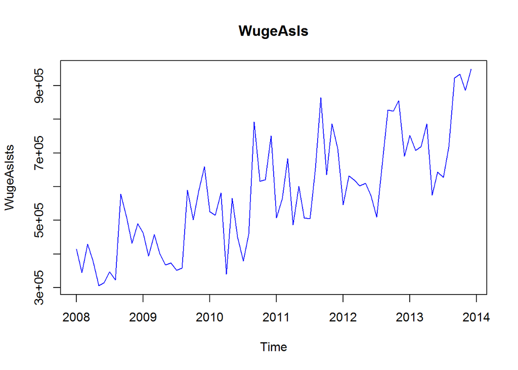

```r
plot(WugeAsIsts, col="blue", main="WugeAsIs")
```

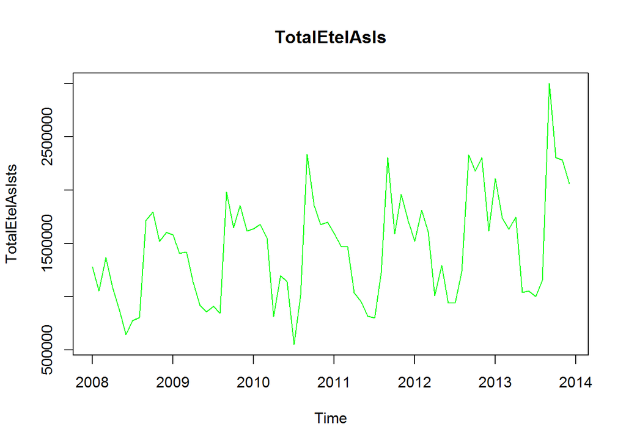

```r
plot(TotalEtelAsIsts, col="green",main="TotalEtelAsIs")
```

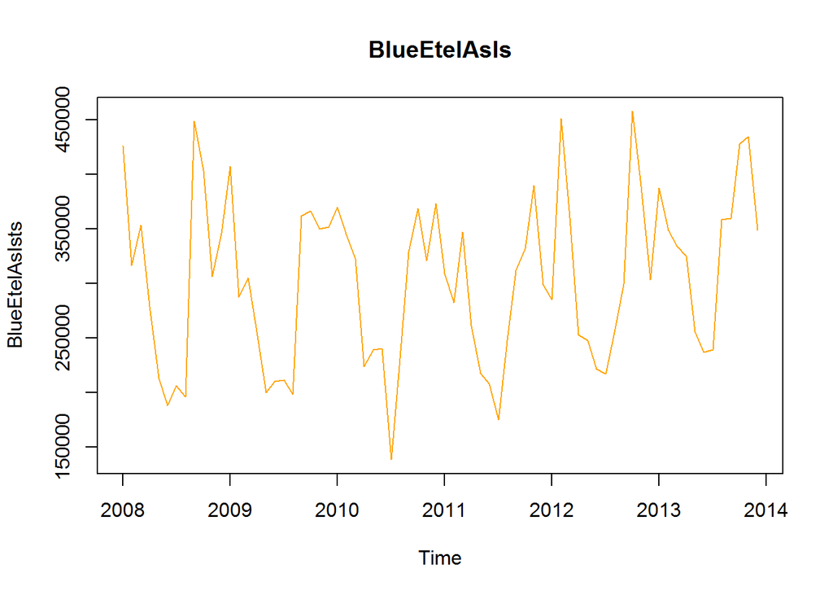

```r
plot(BlueEtelAsIsts, col="orange", main="BlueEtelAsIs")
```

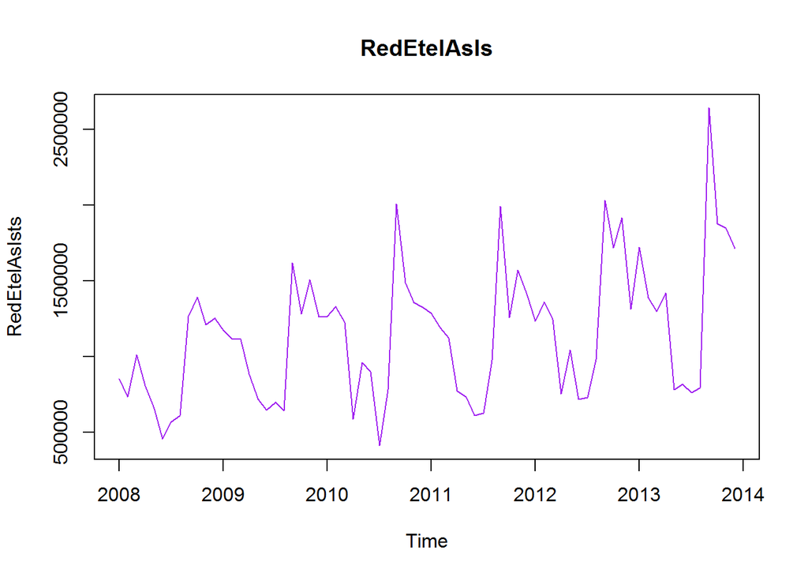

```r
plot(RedEtelAsIsts, col="purple", main="RedEtelAsIs")
```

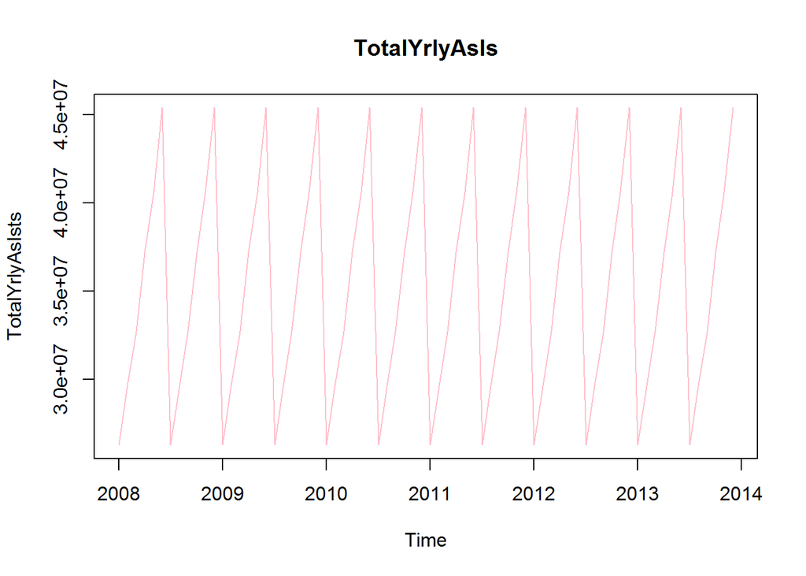

```r
plot(TotalYrlyAsIsts, col="pink", main="TotalYrlyAsIs")
```

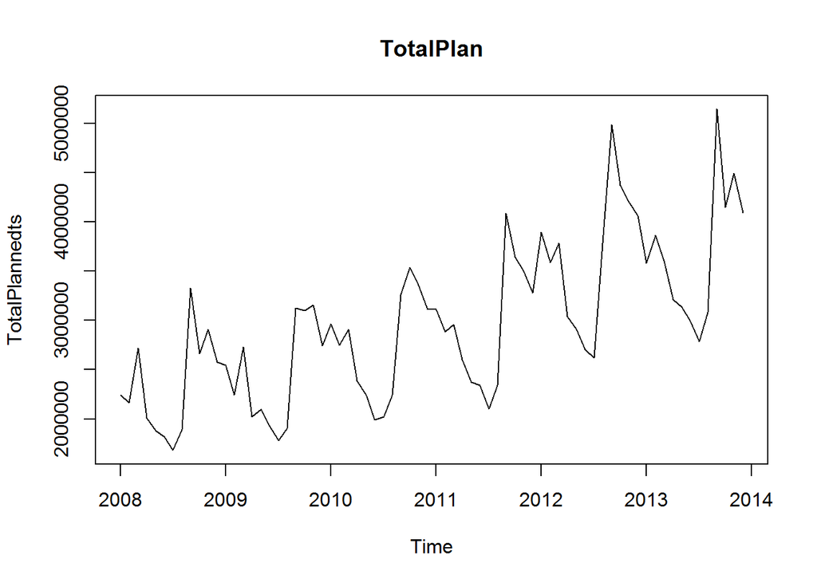

```r
plot(TotalPlannedts , col="black", main="TotalPlan")
```

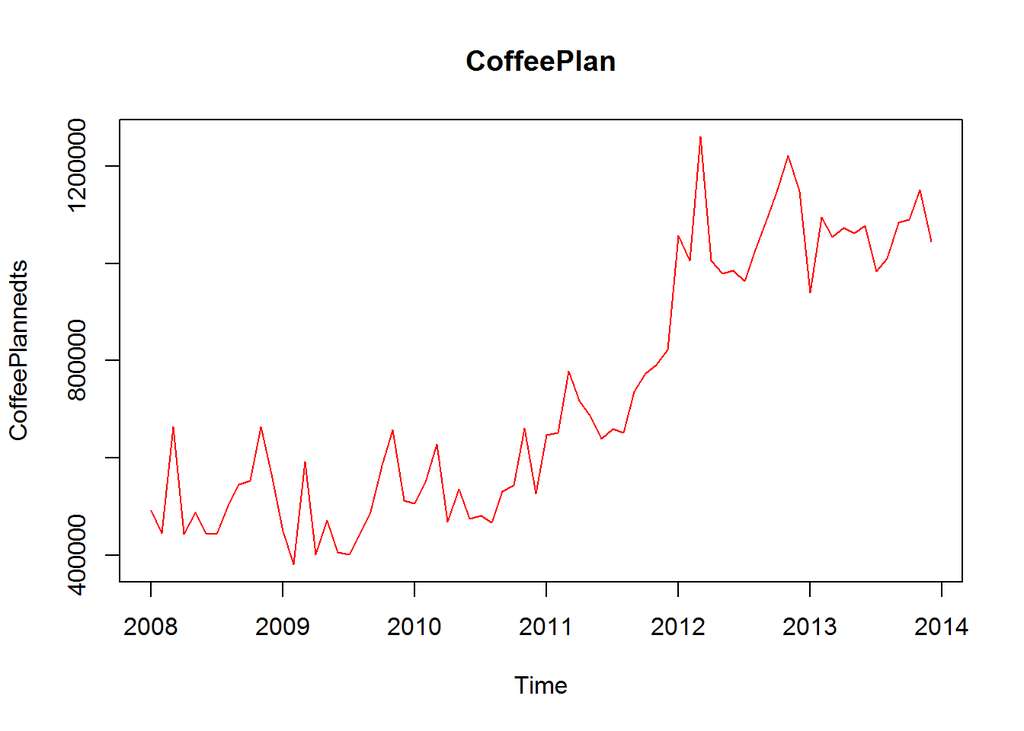

```r
plot(CoffeePlannedts , col="red",main="CoffeePlan")
```

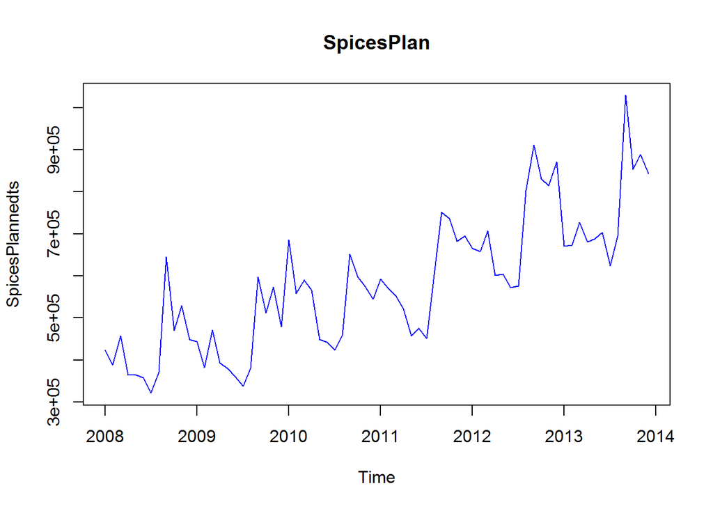

```r
plot(SpicesPlannedts, col="blue", main="SpicesPlan")
```

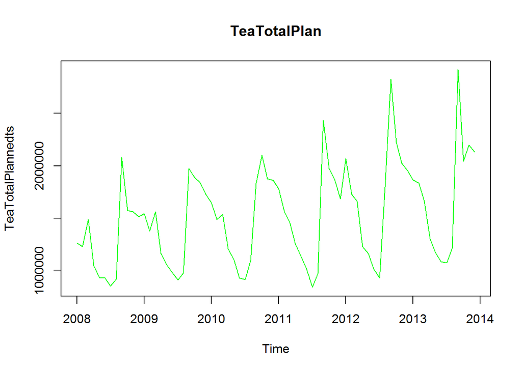

```r
plot(TeaTotalPlannedts, col="green",main="TeaTotalPlan")
```

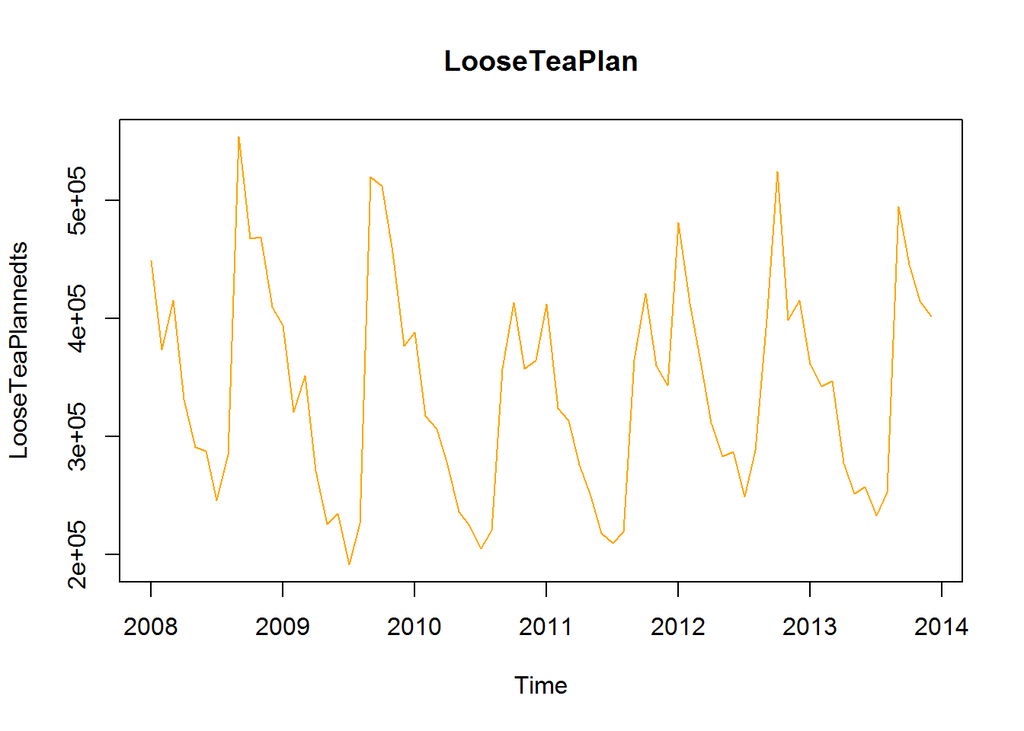

```r
plot(LooseTeaPlannedts, col="orange", main="LooseTeaPlan")
```

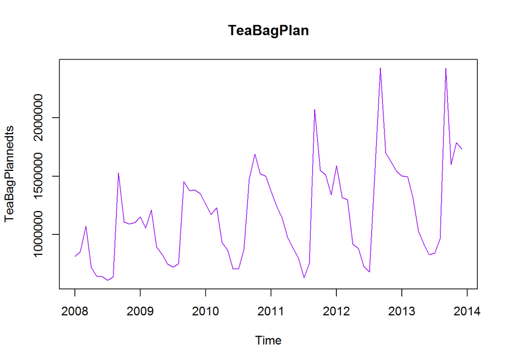

```r
plot(TeaBagPlannedts, col="purple", main="TeaBagPlan")
```

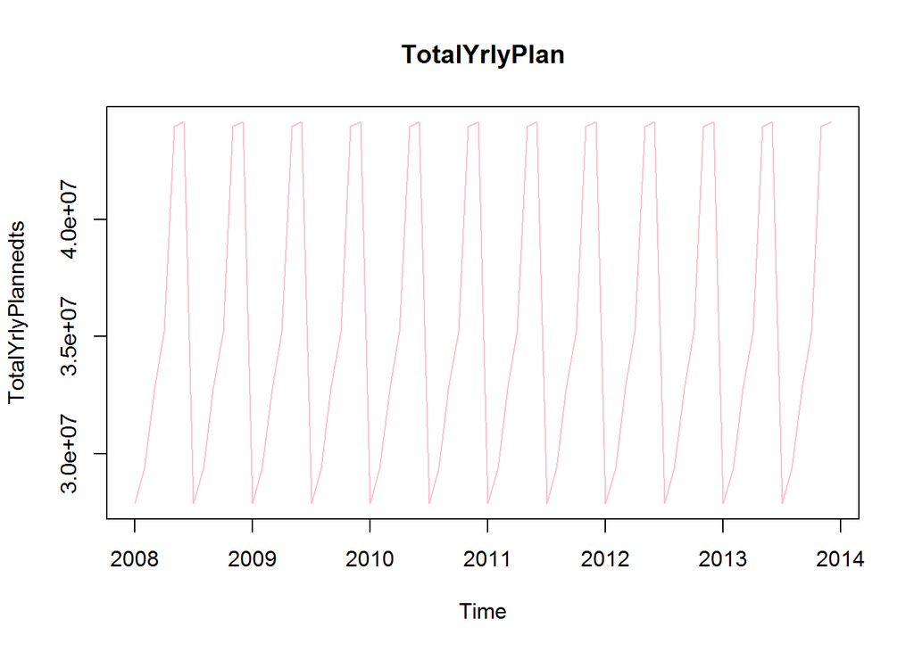

```r
plot(TotalYrlyPlannedts, col="pink", main="TotalYrlyPlan")
```

```r
cor(TotalAsIsts, TotalPlannedts)
```

```
## [1] 0.9183402
```

```r
cor(EfakAsIsts, CoffeePlannedts)
```

```
## [1] 0.9055081
```

```r
cor(EfakAsIsts, SpicesPlannedts)
```

```
## [1] 0.7935298
```

```r
cor(EfakAsIsts, TeaTotalPlannedts)
```

```
## [1] 0.4091799
```

```r
cor(EfakAsIsts, LooseTeaPlannedts)
```

```
## [1] 0.09326936
```

```r
cor(EfakAsIsts, TeaBagPlannedts)
```

```
## [1] 0.4555129
```

```r
cor(WugeAsIsts, CoffeePlannedts)
```

```
## [1] 0.7291765
```

```r
cor(WugeAsIsts, SpicesPlannedts)
```

```
## [1] 0.8788474
```

```r
cor(WugeAsIsts, TeaTotalPlannedts)
```

```
## [1] 0.7220707
```

```r
cor(WugeAsIsts, LooseTeaPlannedts)
```

```
## [1] 0.3676525
```

```r
cor(WugeAsIsts, TeaBagPlannedts)
```

```
## [1] 0.7590231
```

```r
cor(TotalEtelAsIsts, CoffeePlannedts)
```

```
## [1] 0.4286769
```

```r
cor(TotalEtelAsIsts, SpicesPlannedts)
```

```
## [1] 0.7336046
```

```r
cor(TotalEtelAsIsts, TeaTotalPlannedts)
```

```
## [1] 0.9159505
```

```r
cor(TotalEtelAsIsts, LooseTeaPlannedts)
```

```
## [1] 0.7294076
```

```r
cor(TotalEtelAsIsts, TeaBagPlannedts)
```

```
## [1] 0.9047793
```

```r
cor(BlueEtelAsIsts, CoffeePlannedts)
```

```
## [1] 0.2982273
```

```r
cor(BlueEtelAsIsts, SpicesPlannedts)
```

```
## [1] 0.498772
```

```r
cor(BlueEtelAsIsts, TeaTotalPlannedts)
```

```
## [1] 0.7095807
```

```r
cor(BlueEtelAsIsts, LooseTeaPlannedts)
```

```
## [1] 0.8044146
```

```r
cor(BlueEtelAsIsts, TeaBagPlannedts)
```

```
## [1] 0.6481089
```

```r
cor(RedEtelAsIsts, CoffeePlannedts)
```

```
## [1] 0.4329801
```

```r
cor(RedEtelAsIsts, SpicesPlannedts)
```

```
## [1] 0.7429514
```

```r
cor(RedEtelAsIsts, TeaTotalPlannedts)
```

```
## [1] 0.9127691
```

```r
cor(RedEtelAsIsts, LooseTeaPlannedts)
```

```
## [1] 0.6859376
```

```r
cor(RedEtelAsIsts, TeaBagPlannedts)
```

```
## [1] 0.9106702
```

```r
cor(TotalYrlyAsIsts, CoffeePlannedts)
```

```
## [1] 0.08214482
```

```r
cor(TotalYrlyAsIsts, SpicesPlannedts)
```

```
## [1] 0.06794917
```

```r
cor(TotalYrlyAsIsts, TeaTotalPlannedts)
```

```
## [1] 0.03049893
```

```r
cor(TotalYrlyAsIsts, LooseTeaPlannedts)
```

```
## [1] 0.02684453
```

```r
cor(TotalYrlyAsIsts, TeaBagPlannedts)
```

```
## [1] 0.02956264
```

## IV-Linear Modelling including trend and seasonality.

```r
## LM
TotalAsIs_lm <- lm(TotalAsIsts ~ TotalPlannedts , data = TotalAsIsts)
summary(TotalAsIs_lm)
```

```
##
## Call:
## lm(formula = TotalAsIsts ~ TotalPlannedts, data = TotalAsIsts)
##
## Residuals:
##     Min      1Q  Median      3Q     Max
## -770214 -196776   26017  182579  672705
##
## Coefficients:
##                 Estimate Std. Error t value Pr(>|t|)
## (Intercept)    8.959e+04  1.521e+05   0.589    0.558
## TotalPlannedts 9.627e-01  4.959e-02  19.413   <2e-16 ***
## ---
## Signif. codes:  0 '***' 0.001 '**' 0.01 '*' 0.05 '.' 0.1 ' ' 1
##
## Residual standard error: 332600 on 70 degrees of freedom
## Multiple R-squared:  0.8433, Adjusted R-squared:  0.8411
## F-statistic: 376.9 on 1 and 70 DF,  p-value: < 2.2e-16
```

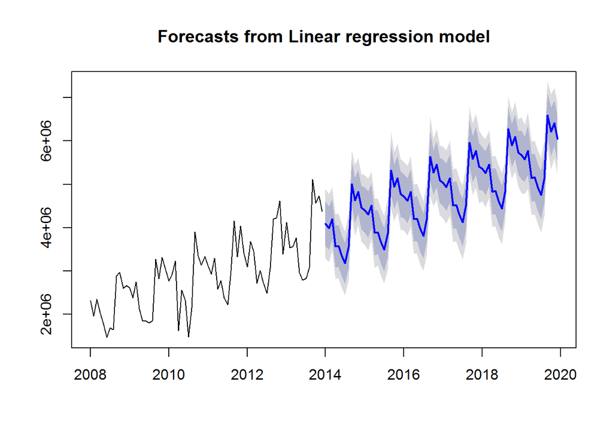

```r
## TSLM
TotalAsIsfit <- tslm(TotalAsIsts ~ TotalPlannedts + trend + season )
plot(forecast(TotalAsIsfit, h=72))
```

```r
##
## LM
EfakAsIstoCoffee_lm <- lm(EfakAsIsts ~ CoffeePlannedts , data = EfakAsIsts)
summary(EfakAsIstoCoffee_lm)
```

```
##
## Call:
## lm(formula = EfakAsIsts ~ CoffeePlannedts, data = EfakAsIsts)
##
## Residuals:
##     Min      1Q  Median      3Q     Max
## -223437  -90637    8593   83869  322479
##
## Coefficients:
##                  Estimate Std. Error t value Pr(>|t|)
## (Intercept)     7.555e+04  4.005e+04   1.886   0.0634 .
## CoffeePlannedts 9.236e-01  5.173e-02  17.854   <2e-16 ***
## ---
## Signif. codes:  0 '***' 0.001 '**' 0.01 '*' 0.05 '.' 0.1 ' ' 1
##
## Residual standard error: 113600 on 70 degrees of freedom
## Multiple R-squared:  0.8199, Adjusted R-squared:  0.8174
## F-statistic: 318.8 on 1 and 70 DF,  p-value: < 2.2e-16
```

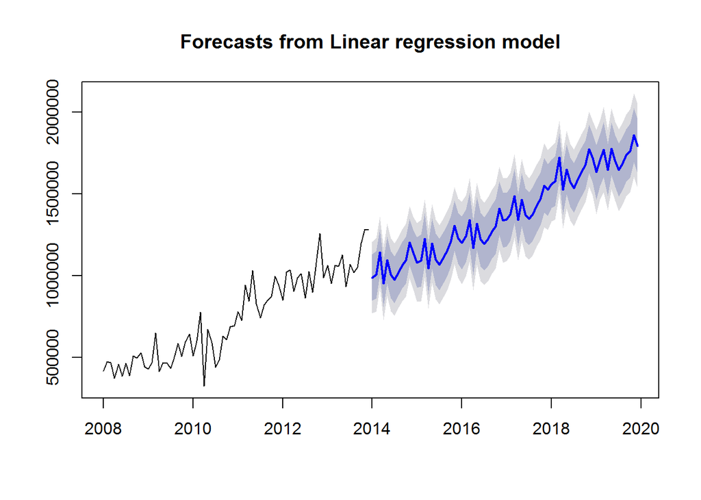

```r
## TSLM
EfakAsIsfit <- tslm(EfakAsIsts ~ CoffeePlannedts + trend + season )
plot(forecast(EfakAsIsfit, h=72))
```

```r
## LM
EfakAsIstoSpices_lm <- lm(EfakAsIsts ~ SpicesPlannedts , data = EfakAsIsts)
summary(EfakAsIstoSpices_lm)
```

```
##
## Call:
## lm(formula = EfakAsIsts ~ SpicesPlannedts, data = EfakAsIsts)
##
## Residuals:
##     Min      1Q  Median      3Q     Max
## -407493 -112218     597  118465  441925
##
## Coefficients:
##                   Estimate Std. Error t value Pr(>|t|)
## (Intercept)     -1.594e+04  7.274e+04  -0.219    0.827
## SpicesPlannedts  1.319e+00  1.209e-01  10.910   <2e-16 ***
## ---
## Signif. codes:  0 '***' 0.001 '**' 0.01 '*' 0.05 '.' 0.1 ' ' 1
##
## Residual standard error: 162900 on 70 degrees of freedom
## Multiple R-squared:  0.6297, Adjusted R-squared:  0.6244
## F-statistic:   119 on 1 and 70 DF,  p-value: < 2.2e-16
```

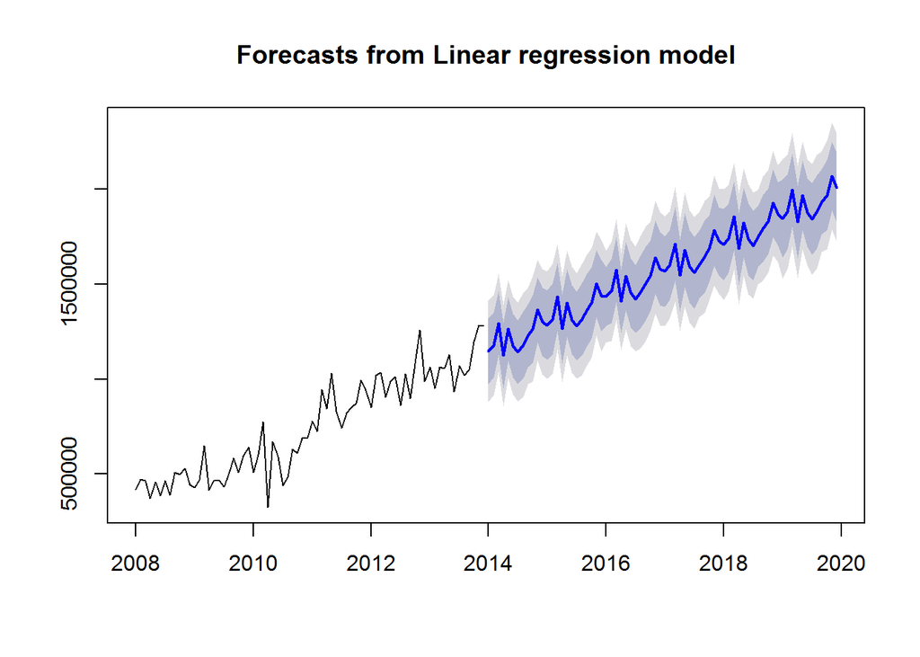

```r
## TSLM
EfakAsIstoSpicesfit <- tslm(EfakAsIsts ~ SpicesPlannedts + trend + season )
plot(forecast(EfakAsIstoSpicesfit, h=72))
```

```r
## LM
EfakAsIstoTeaTotal_lm <- lm(EfakAsIsts ~ TeaTotalPlannedts , data = EfakAsIsts)
summary(EfakAsIstoTeaTotal_lm)
```

```
##
## Call:
## lm(formula = EfakAsIsts ~ TeaTotalPlannedts, data = EfakAsIsts)
##
## Residuals:
##     Min      1Q  Median      3Q     Max
## -369770 -215214  -32749  213977  456879
##
## Coefficients:
##                    Estimate Std. Error t value Pr(>|t|)
## (Intercept)       4.038e+05  9.653e+04   4.183 8.21e-05 ***
## TeaTotalPlannedts 2.279e-01  6.075e-02   3.752 0.000359 ***
## ---
## Signif. codes:  0 '***' 0.001 '**' 0.01 '*' 0.05 '.' 0.1 ' ' 1
##
## Residual standard error: 244300 on 70 degrees of freedom
## Multiple R-squared:  0.1674, Adjusted R-squared:  0.1555
## F-statistic: 14.08 on 1 and 70 DF,  p-value: 0.0003586
```

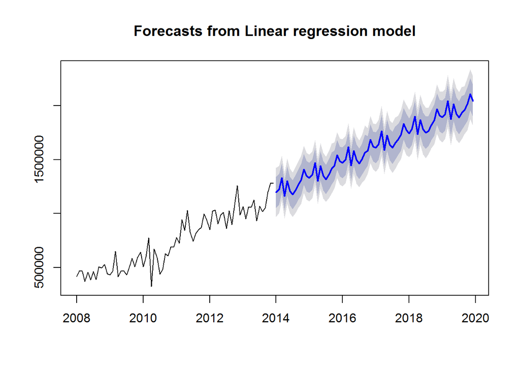

```r
## TSLM
EfakAsIstoTeaTotalfit <- tslm(EfakAsIsts ~ TeaTotalPlannedts + trend + season )
plot(forecast(EfakAsIstoTeaTotalfit, h=72))
```

```r
## LM
EfakAsIstoLooseTea_lm <- lm(EfakAsIsts ~ LooseTeaPlannedts , data = EfakAsIsts)
summary(EfakAsIstoLooseTea_lm)
```

```
##
## Call:
## lm(formula = EfakAsIsts ~ LooseTeaPlannedts, data = EfakAsIsts)
##
## Residuals:
##     Min      1Q  Median      3Q     Max
## -408248 -256355   -4557  244447  514560
##
## Coefficients:
##                    Estimate Std. Error t value Pr(>|t|)
## (Intercept)       6.562e+05  1.232e+05   5.327 1.15e-06 ***
## LooseTeaPlannedts 2.740e-01  3.495e-01   0.784    0.436
## ---
## Signif. codes:  0 '***' 0.001 '**' 0.01 '*' 0.05 '.' 0.1 ' ' 1
##
## Residual standard error: 266500 on 70 degrees of freedom
## Multiple R-squared:  0.008699,   Adjusted R-squared:  -0.005462
## F-statistic: 0.6143 on 1 and 70 DF,  p-value: 0.4358
```

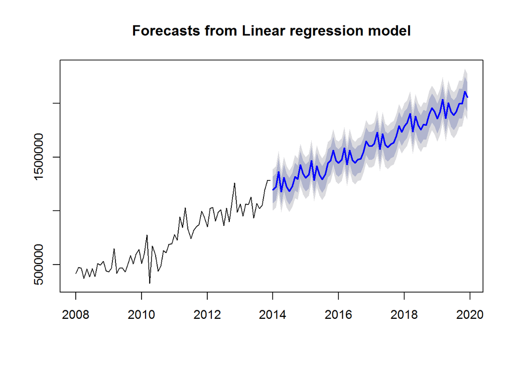

```r
## TSLM
EfakAsIstoLooseTeafit <- tslm(EfakAsIsts ~ LooseTeaPlannedts + trend + season )
plot(forecast(EfakAsIstoLooseTeafit, h=72))
```

```r
## LM
EfakAsIstoTeaBag_lm <- lm(EfakAsIsts ~ TeaBagPlannedts , data = EfakAsIsts)
summary(EfakAsIstoTeaBag_lm)
```

```
##
## Call:
## lm(formula = EfakAsIsts ~ TeaBagPlannedts, data = EfakAsIsts)
##
## Residuals:
##     Min      1Q  Median      3Q     Max
## -354186 -203338  -54825  207447  453741
##
## Coefficients:
##                  Estimate Std. Error t value Pr(>|t|)
## (Intercept)     4.023e+05  8.583e+04   4.688 1.32e-05 ***
## TeaBagPlannedts 2.953e-01  6.897e-02   4.281 5.81e-05 ***
## ---
## Signif. codes:  0 '***' 0.001 '**' 0.01 '*' 0.05 '.' 0.1 ' ' 1
##
## Residual standard error: 238300 on 70 degrees of freedom
## Multiple R-squared:  0.2075, Adjusted R-squared:  0.1962
## F-statistic: 18.33 on 1 and 70 DF,  p-value: 5.805e-05
```

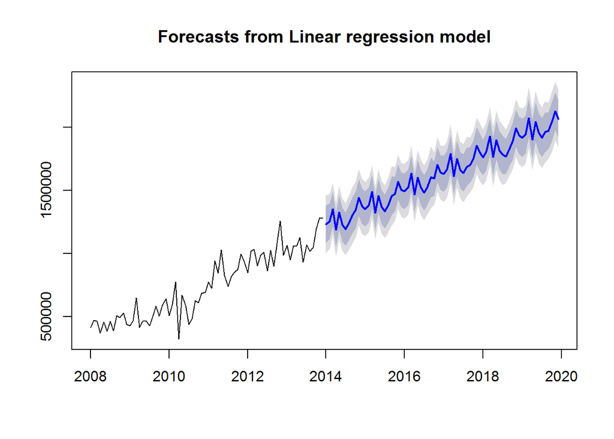

```r
## TSLM
EfakAsIstoTeaBagfit <- tslm(EfakAsIsts ~ TeaBagPlannedts + trend + season )
plot(forecast(EfakAsIstoTeaBagfit, h=72))
```

```r
##
## LM of WugeAsIs to Planned Series
##
## LM
WugeAsIstoCoffee_lm <- lm(WugeAsIsts ~ CoffeePlannedts , data = WugeAsIsts)
summary(WugeAsIstoCoffee_lm)
```

```
##
## Call:
## lm(formula = WugeAsIsts ~ CoffeePlannedts, data = WugeAsIsts)
##
## Residuals:
##     Min      1Q  Median      3Q     Max
## -207174  -85638  -10328   74350  305633
##
## Coefficients:
##                  Estimate Std. Error t value Pr(>|t|)
## (Intercept)     2.378e+05  4.057e+04   5.861 1.37e-07 ***
## CoffeePlannedts 4.671e-01  5.240e-02   8.915 3.79e-13 ***
## ---
## Signif. codes:  0 '***' 0.001 '**' 0.01 '*' 0.05 '.' 0.1 ' ' 1
##
## Residual standard error: 115100 on 70 degrees of freedom
## Multiple R-squared:  0.5317, Adjusted R-squared:  0.525
## F-statistic: 79.48 on 1 and 70 DF,  p-value: 3.787e-13
```

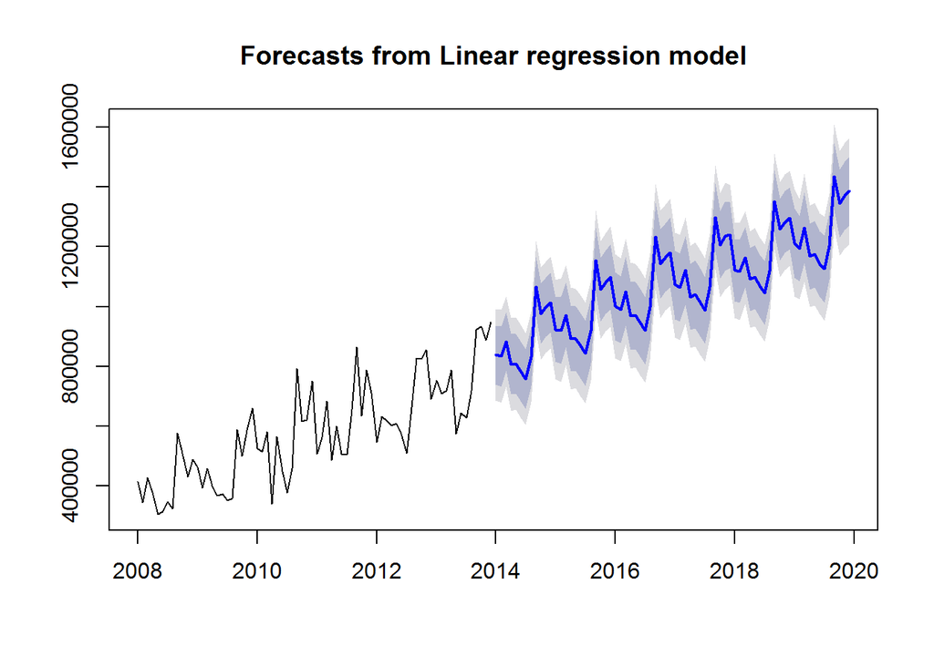

```r
## TSLM
WugeAsIstoCoffeefit <- tslm(WugeAsIsts ~ CoffeePlannedts + trend + season )
plot(forecast(WugeAsIstoCoffeefit, h=72))
```

```r
## LM
WugeAsIstoSpices_lm <- lm(WugeAsIsts ~ SpicesPlannedts , data = WugeAsIsts)
summary(WugeAsIstoSpices_lm)
```

```
##
## Call:
## lm(formula = WugeAsIsts ~ SpicesPlannedts, data = WugeAsIsts)
##
## Residuals:
##     Min      1Q  Median      3Q     Max
## -225162  -55052   -2998   32989  204947
##
## Coefficients:
##                  Estimate Std. Error t value Pr(>|t|)
## (Intercept)     4.620e+04  3.582e+04    1.29    0.201
## SpicesPlannedts 9.178e-01  5.955e-02   15.41   <2e-16 ***
## ---
## Signif. codes:  0 '***' 0.001 '**' 0.01 '*' 0.05 '.' 0.1 ' ' 1
##
## Residual standard error: 80220 on 70 degrees of freedom
## Multiple R-squared:  0.7724, Adjusted R-squared:  0.7691
## F-statistic: 237.5 on 1 and 70 DF,  p-value: < 2.2e-16
```

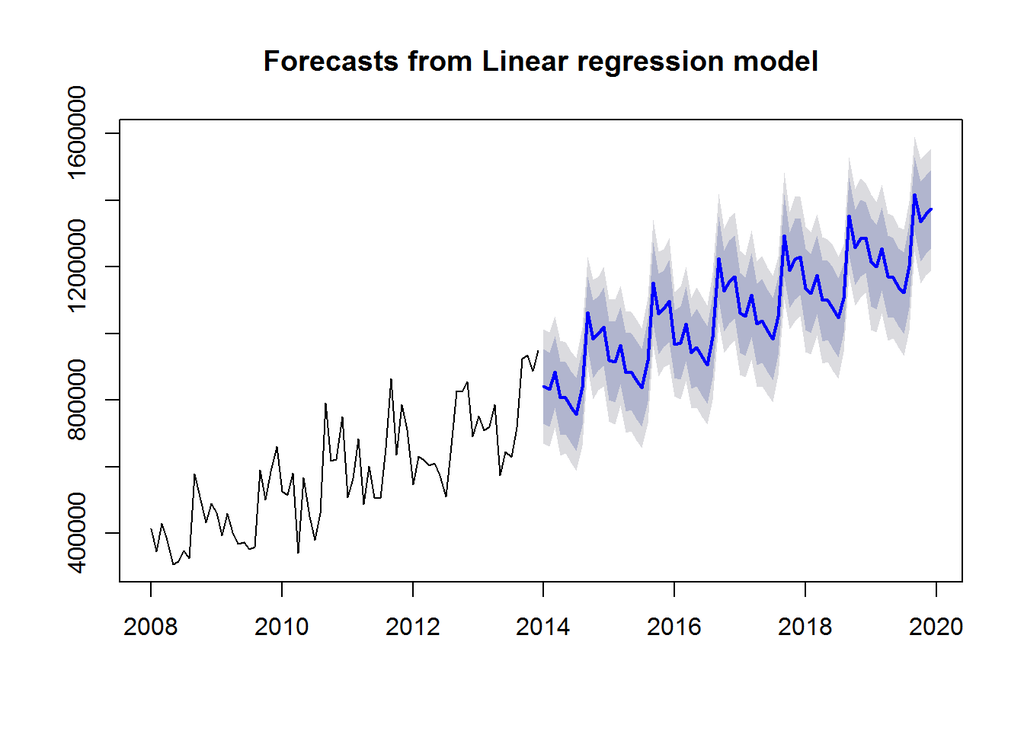

```r
## TSLM
WugeAsIstoSpicesfit <- tslm(WugeAsIsts ~ SpicesPlannedts + trend + season )
plot(forecast(WugeAsIstoSpicesfit, h=72))
```

```r
## LM
WugeAsIstoTeaTotal_lm <- lm(WugeAsIsts ~ TeaTotalPlannedts , data = WugeAsIsts)
summary(WugeAsIstoTeaTotal_lm)
```

```
##
## Call:
## lm(formula = WugeAsIsts ~ TeaTotalPlannedts, data = WugeAsIsts)
##
## Residuals:
##     Min      1Q  Median      3Q     Max
## -172586  -90152  -10786   92305  262005
##
## Coefficients:
##                    Estimate Std. Error t value Pr(>|t|)
## (Intercept)       1.955e+05  4.597e+04   4.253 6.42e-05 ***
## TeaTotalPlannedts 2.526e-01  2.893e-02   8.732 8.19e-13 ***
## ---
## Signif. codes:  0 '***' 0.001 '**' 0.01 '*' 0.05 '.' 0.1 ' ' 1
##
## Residual standard error: 116300 on 70 degrees of freedom
## Multiple R-squared:  0.5214, Adjusted R-squared:  0.5145
## F-statistic: 76.26 on 1 and 70 DF,  p-value: 8.192e-13
```

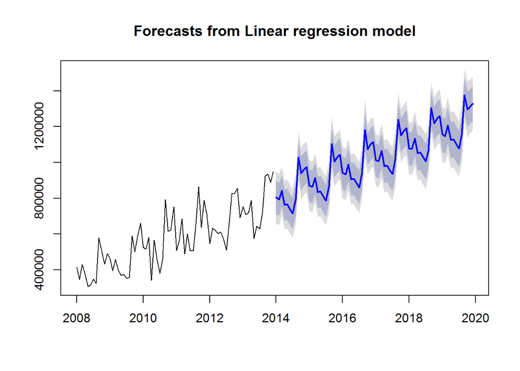

```r
##
## TSLM
WugeAsIstoTeaTotalfit <- tslm(WugeAsIsts ~ TeaTotalPlannedts + trend + season )
plot(forecast(WugeAsIstoTeaTotalfit, h=72))
```

```r
## LM
WugeAsIstoLooseTea_lm <- lm(WugeAsIsts ~ LooseTeaPlannedts , data = WugeAsIsts)
summary(WugeAsIstoLooseTea_lm)
```

```
##
## Call:
## lm(formula = WugeAsIsts ~ LooseTeaPlannedts, data = WugeAsIsts)
##
## Residuals:
##     Min      1Q  Median      3Q     Max
## -256441 -133091    3523  123076  328794
##
## Coefficients:
##                    Estimate Std. Error t value Pr(>|t|)
## (Intercept)       3.476e+05  7.226e+04   4.810 8.37e-06 ***
## LooseTeaPlannedts 6.783e-01  2.051e-01   3.308  0.00149 **
## ---
## Signif. codes:  0 '***' 0.001 '**' 0.01 '*' 0.05 '.' 0.1 ' ' 1
##
## Residual standard error: 156400 on 70 degrees of freedom
## Multiple R-squared:  0.1352, Adjusted R-squared:  0.1228
## F-statistic: 10.94 on 1 and 70 DF,  p-value: 0.001488
```

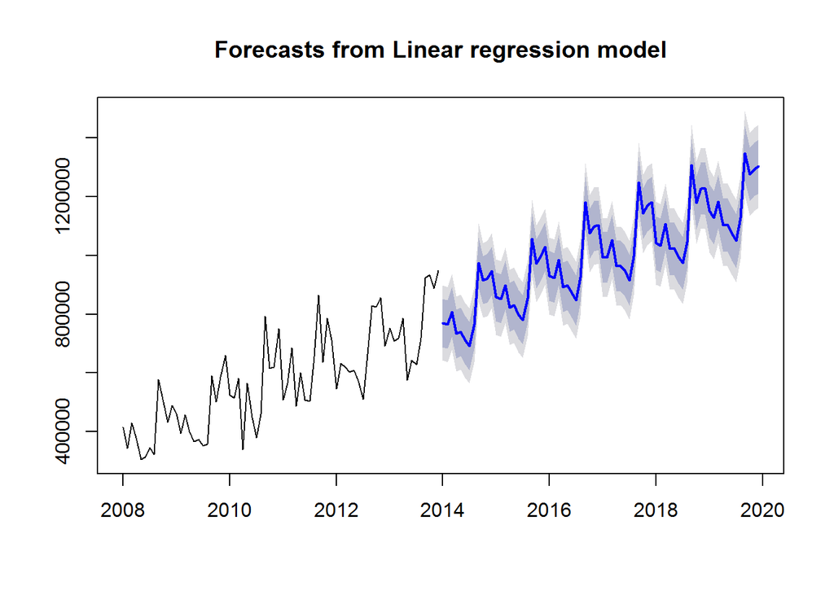

```r
## TSLM
WugeAsIstoLooseTeafit <- tslm(WugeAsIsts ~ LooseTeaPlannedts + trend + season )
plot(forecast(WugeAsIstoLooseTeafit, h=72))
```

```r
## LM
WugeAsIstoTeaBag_lm <- lm(WugeAsIsts ~ TeaBagPlannedts , data = WugeAsIsts)
summary(WugeAsIstoTeaBag_lm)
```

```
##
## Call:
## lm(formula = WugeAsIsts ~ TeaBagPlannedts, data = WugeAsIsts)
##
## Residuals:
##     Min      1Q  Median      3Q     Max
## -162876  -89179  -28911   86372  254375
##
## Coefficients:
##                  Estimate Std. Error t value Pr(>|t|)
## (Intercept)     2.153e+05  3.942e+04   5.461 6.79e-07 ***
## TeaBagPlannedts 3.090e-01  3.168e-02   9.754 1.11e-14 ***
## ---
## Signif. codes:  0 '***' 0.001 '**' 0.01 '*' 0.05 '.' 0.1 ' ' 1
##
## Residual standard error: 109500 on 70 degrees of freedom
## Multiple R-squared:  0.5761, Adjusted R-squared:  0.5701
## F-statistic: 95.14 on 1 and 70 DF,  p-value: 1.114e-14
```

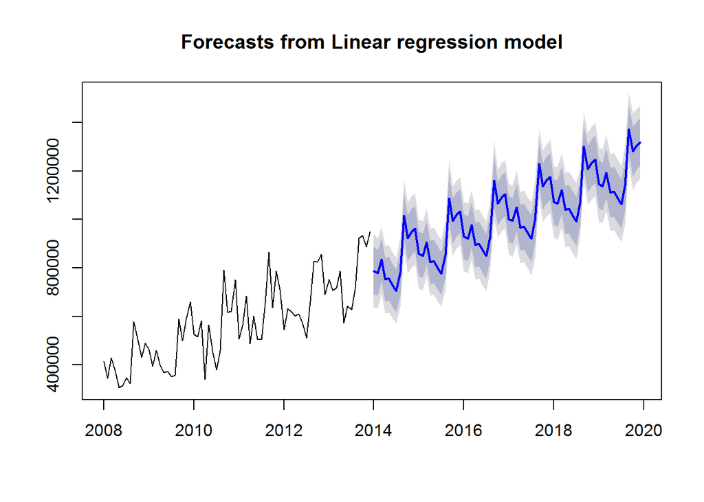

```r
## TSLM
WugeAsIstoTeaBagfit <- tslm(WugeAsIsts ~ TeaBagPlannedts + trend + season )
plot(forecast(WugeAsIstoTeaBagfit, h=72))
```

```r
##
##
## LM
TotalEtelAsIs_lm <- lm(TotalEtelAsIsts ~ TotalPlannedts , data = TotalEtelAsIsts)
summary(TotalEtelAsIs_lm)
```

```
##
## Call:
## lm(formula = TotalEtelAsIsts ~ TotalPlannedts, data = TotalEtelAsIsts)
##
## Residuals:
##     Min      1Q  Median      3Q     Max
## -655899 -197079   25532  183422  724612
##
## Coefficients:
##                  Estimate Std. Error t value Pr(>|t|)
## (Intercept)    -1.215e+05  1.244e+05  -0.977    0.332
## TotalPlannedts  5.318e-01  4.055e-02  13.115   <2e-16 ***
## ---
## Signif. codes:  0 '***' 0.001 '**' 0.01 '*' 0.05 '.' 0.1 ' ' 1
##
## Residual standard error: 271900 on 70 degrees of freedom
## Multiple R-squared:  0.7107, Adjusted R-squared:  0.7066
## F-statistic:   172 on 1 and 70 DF,  p-value: < 2.2e-16
```

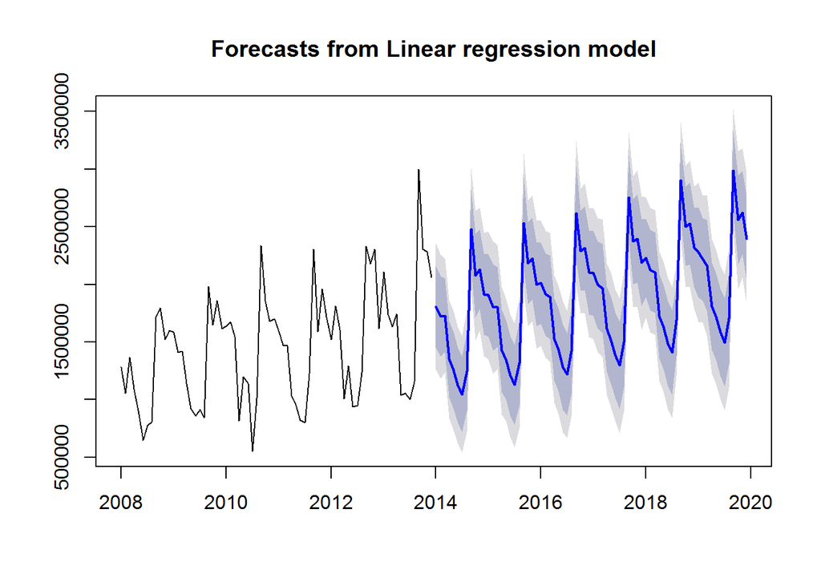

```r
## TSLM
TotalEtelAsIsfit <- tslm(TotalEtelAsIsts ~ TotalPlannedts + trend + season )
plot(forecast(TotalEtelAsIsfit, h=72))
```

```r
##LM
TotalEtelAsIstoCoffee_lm <- lm(TotalEtelAsIsts ~ CoffeePlannedts , data = TotalEtelAsIsts)
summary(TotalEtelAsIstoCoffee_lm)
```

```
##
## Call:
## lm(formula = TotalEtelAsIsts ~ CoffeePlannedts, data = TotalEtelAsIsts)
##
## Residuals:
##     Min      1Q  Median      3Q     Max
## -725498 -376946  -21170  361294 1254353
##
## Coefficients:
##                  Estimate Std. Error t value Pr(>|t|)
## (Intercept)     8.518e+05  1.611e+05   5.289 1.34e-06 ***
## CoffeePlannedts 8.258e-01  2.080e-01   3.970 0.000172 ***
## ---
## Signif. codes:  0 '***' 0.001 '**' 0.01 '*' 0.05 '.' 0.1 ' ' 1
##
## Residual standard error: 456800 on 70 degrees of freedom
## Multiple R-squared:  0.1838, Adjusted R-squared:  0.1721
## F-statistic: 15.76 on 1 and 70 DF,  p-value: 0.000172
```

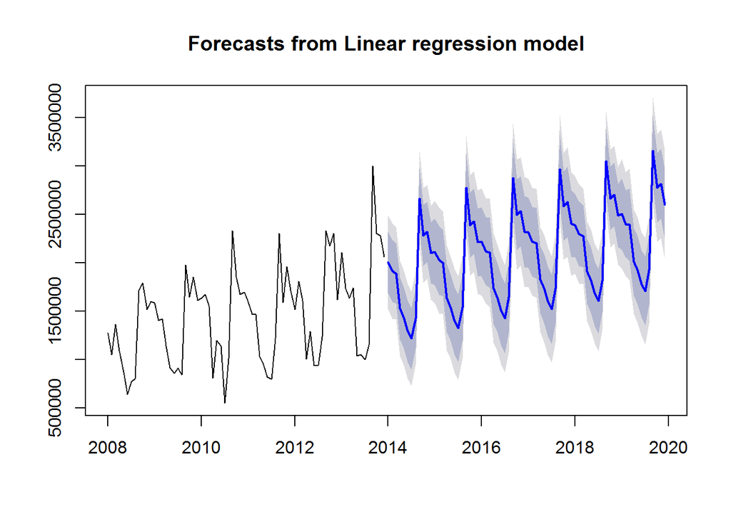

```r
## TSLM
TotalEtelAsIstoCoffeefit <- tslm(TotalEtelAsIsts ~ CoffeePlannedts + trend + season )
plot(forecast(TotalEtelAsIstoCoffeefit, h=72))
```

```r
## LM
TotalEtelAsIsSpices_lm <- lm(TotalEtelAsIsts ~ SpicesPlannedts , data = TotalEtelAsIsts)
summary(TotalEtelAsIsSpices_lm)
```

```
##
## Call:
## lm(formula = TotalEtelAsIsts ~ SpicesPlannedts, data = TotalEtelAsIsts)
##
## Residuals:
##     Min      1Q  Median      3Q     Max
## -731802 -218691   44161  224244  716656
##
## Coefficients:
##                  Estimate Std. Error t value Pr(>|t|)
## (Intercept)     1.179e+05  1.534e+05   0.768    0.445
## SpicesPlannedts 2.304e+00  2.551e-01   9.032 2.31e-13 ***
## ---
## Signif. codes:  0 '***' 0.001 '**' 0.01 '*' 0.05 '.' 0.1 ' ' 1
##
## Residual standard error: 343600 on 70 degrees of freedom
## Multiple R-squared:  0.5382, Adjusted R-squared:  0.5316
## F-statistic: 81.57 on 1 and 70 DF,  p-value: 2.312e-13
```

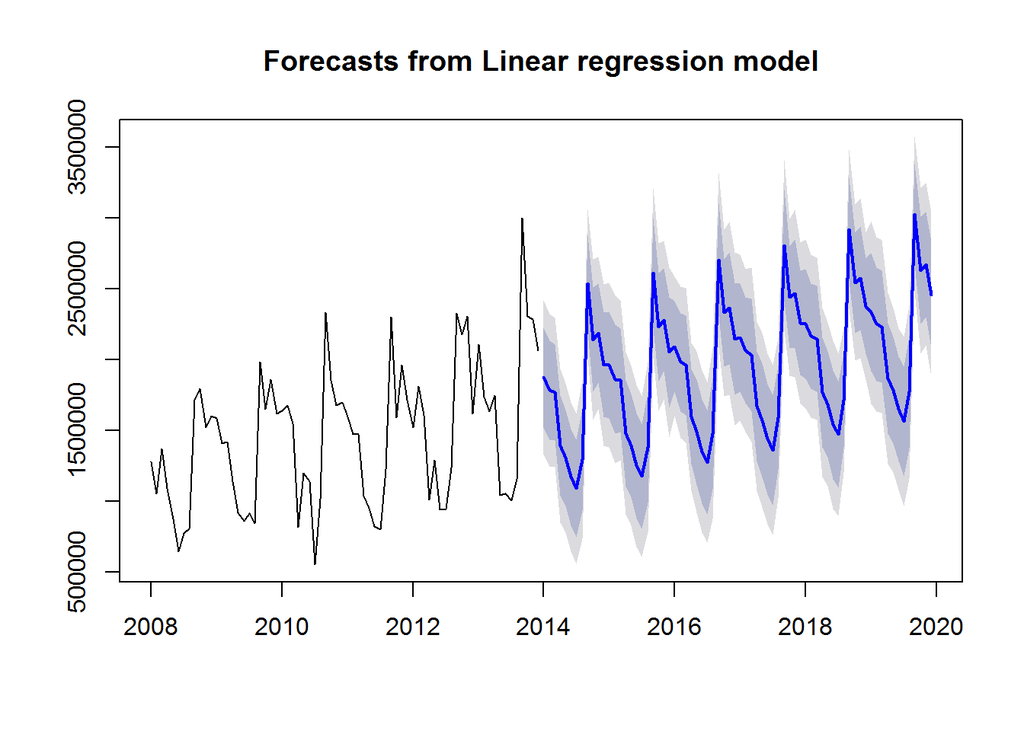

```r
## TSLM
TotalEtelAsIstoSpicesfit <- tslm(TotalEtelAsIsts ~ SpicesPlannedts + trend + season )
plot(forecast(TotalEtelAsIstoSpicesfit, h=72))
```

```r
## LM
TotalEtelAsIstoTeaTotal_lm <- lm(TotalEtelAsIsts ~ TeaTotalPlannedts , data = TotalEtelAsIsts)
summary(TotalEtelAsIstoTeaTotal_lm)
```

```
##
## Call:
## lm(formula = TotalEtelAsIsts ~ TeaTotalPlannedts, data = TotalEtelAsIsts)
##
## Residuals:
##     Min      1Q  Median      3Q     Max
## -492888  -99871   -7667   93858  576321
##
## Coefficients:
##                     Estimate Std. Error t value Pr(>|t|)
## (Intercept)       -7.175e+03  8.018e+04  -0.089    0.929
## TeaTotalPlannedts  9.637e-01  5.046e-02  19.097   <2e-16 ***
## ---
## Signif. codes:  0 '***' 0.001 '**' 0.01 '*' 0.05 '.' 0.1 ' ' 1
##
## Residual standard error: 202900 on 70 degrees of freedom
## Multiple R-squared:  0.839,  Adjusted R-squared:  0.8367
## F-statistic: 364.7 on 1 and 70 DF,  p-value: < 2.2e-16
```

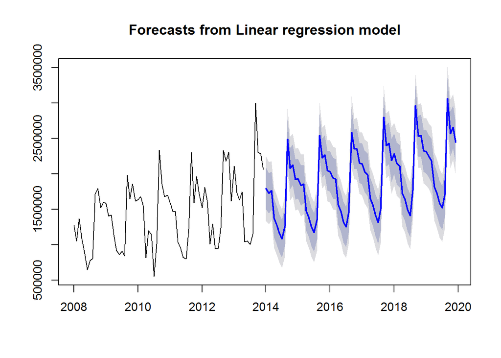

```r
## TSLM
TotalEtelAsIstoTeaTotalfit <- tslm(TotalEtelAsIsts ~ TeaTotalPlannedts + trend + season )
plot(forecast(TotalEtelAsIstoTeaTotalfit, h=72))
```

```r
## LM
TotalEtelAsIstoLooseTea_lm <- lm(TotalEtelAsIsts ~ LooseTeaPlannedts , data = TotalEtelAsIsts)
summary(TotalEtelAsIstoLooseTea_lm)
```

```
##
## Call:
## lm(formula = TotalEtelAsIsts ~ LooseTeaPlannedts, data = TotalEtelAsIsts)
##
## Residuals:
##     Min      1Q  Median      3Q     Max
## -613754 -177126  -26355  155573  922927
##
## Coefficients:
##                    Estimate Std. Error t value Pr(>|t|)
## (Intercept)       7.567e+04  1.598e+05   0.473    0.637
## LooseTeaPlannedts 4.046e+00  4.536e-01   8.921 3.69e-13 ***
## ---
## Signif. codes:  0 '***' 0.001 '**' 0.01 '*' 0.05 '.' 0.1 ' ' 1
##
## Residual standard error: 345900 on 70 degrees of freedom
## Multiple R-squared:  0.532,  Adjusted R-squared:  0.5254
## F-statistic: 79.58 on 1 and 70 DF,  p-value: 3.691e-13
```

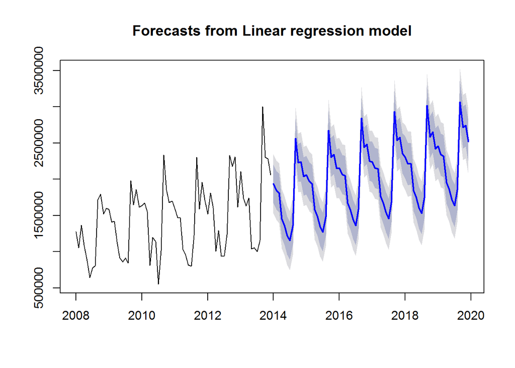

```r
## TSLM
TotalEtelAsIstoLooseTeafit <- tslm(TotalEtelAsIsts ~ LooseTeaPlannedts + trend + season )
plot(forecast(TotalEtelAsIstoLooseTeafit, h=72))
```

```r
## LM
TotalEtelAsIstoTeaBag_lm <- lm(TotalEtelAsIsts ~ TeaBagPlannedts , data = TotalEtelAsIsts)
summary(TotalEtelAsIstoTeaBag_lm)
```

```
##
## Call:
## lm(formula = TotalEtelAsIsts ~ TeaBagPlannedts, data = TotalEtelAsIsts)
##
## Residuals:
##     Min      1Q  Median      3Q     Max
## -591783 -128892  -20519  154789  549048
##
## Coefficients:
##                  Estimate Std. Error t value Pr(>|t|)
## (Intercept)     1.520e+05  7.755e+04   1.959    0.054 .
## TeaBagPlannedts 1.108e+00  6.231e-02  17.775   <2e-16 ***
## ---
## Signif. codes:  0 '***' 0.001 '**' 0.01 '*' 0.05 '.' 0.1 ' ' 1
##
## Residual standard error: 215300 on 70 degrees of freedom
## Multiple R-squared:  0.8186, Adjusted R-squared:  0.816
## F-statistic: 315.9 on 1 and 70 DF,  p-value: < 2.2e-16
```

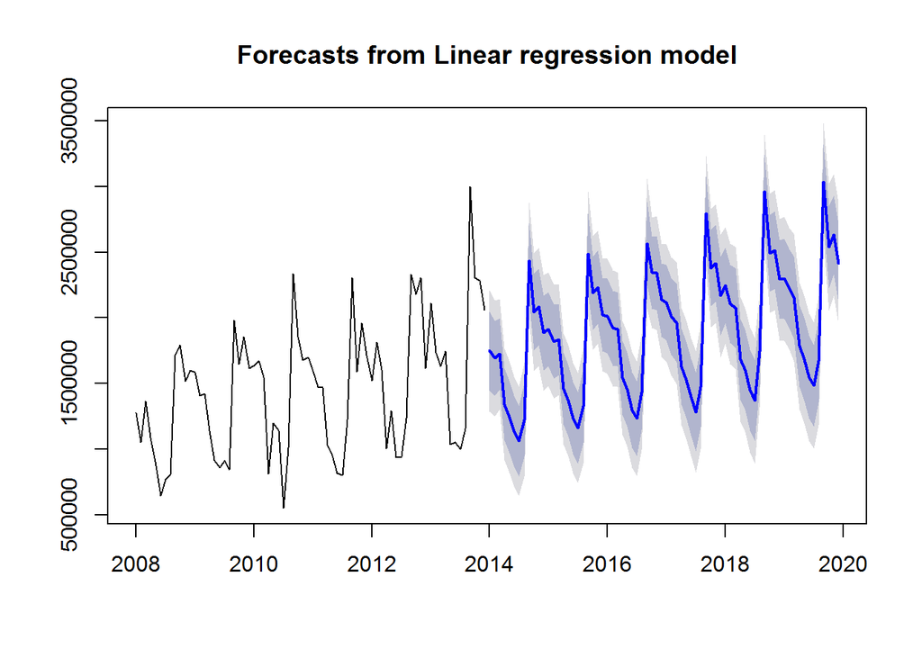

```r
## TSLM
TotalEtelAsIstoTeaBagfit <- tslm(TotalEtelAsIsts ~ TeaBagPlannedts + trend + season )
plot(forecast(TotalEtelAsIstoTeaBagfit, h=72))
```

```r
##
##
## LM
BlueEtelAsIs_lm <- lm(BlueEtelAsIsts ~ TotalPlannedts , data = BlueEtelAsIsts)
summary(BlueEtelAsIs_lm)
```

```
##
## Call:
## lm(formula = BlueEtelAsIsts ~ TotalPlannedts, data = BlueEtelAsIsts)
##
## Residuals:
##     Min      1Q  Median      3Q     Max
## -124515  -48574   -6977   47220  165044
##
## Coefficients:
##                 Estimate Std. Error t value Pr(>|t|)
## (Intercept)    1.274e+05  2.741e+04   4.647 1.54e-05 ***
## TotalPlannedts 5.951e-02  8.936e-03   6.660 5.17e-09 ***
## ---
## Signif. codes:  0 '***' 0.001 '**' 0.01 '*' 0.05 '.' 0.1 ' ' 1
##
## Residual standard error: 59920 on 70 degrees of freedom
## Multiple R-squared:  0.3879, Adjusted R-squared:  0.3791
## F-statistic: 44.36 on 1 and 70 DF,  p-value: 5.172e-09
```

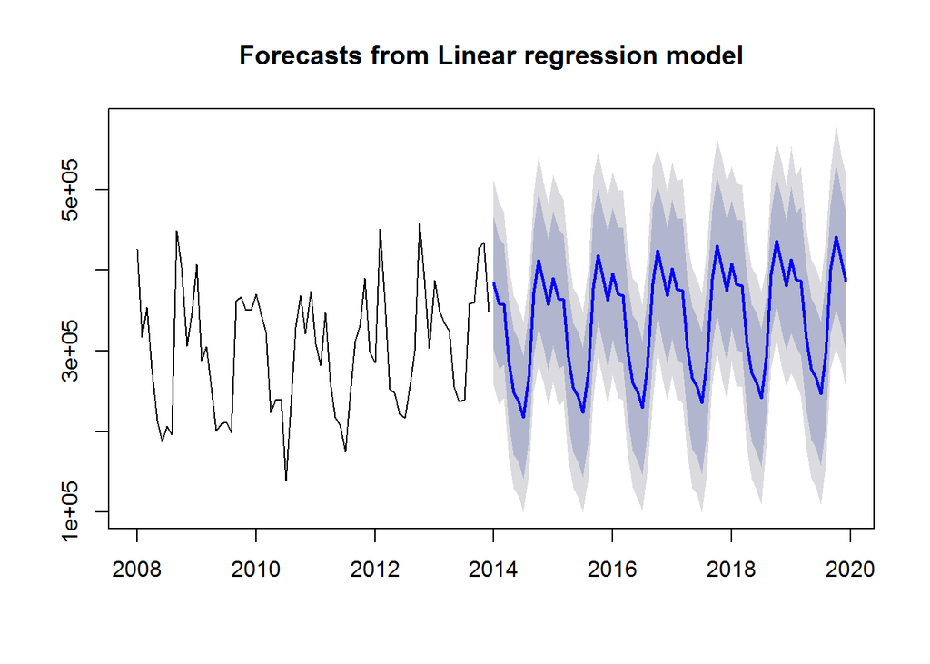

```r
## TSLM
BlueEtelAsIsfit <- tslm(BlueEtelAsIsts ~ TotalPlannedts + trend + season )
plot(forecast(BlueEtelAsIsfit, h=72))
```